# Problem Statement:

# By considering the TOP FUELS like Desile, Petrol and Electric

# Which car brands tend to have higher or lower prices on average?

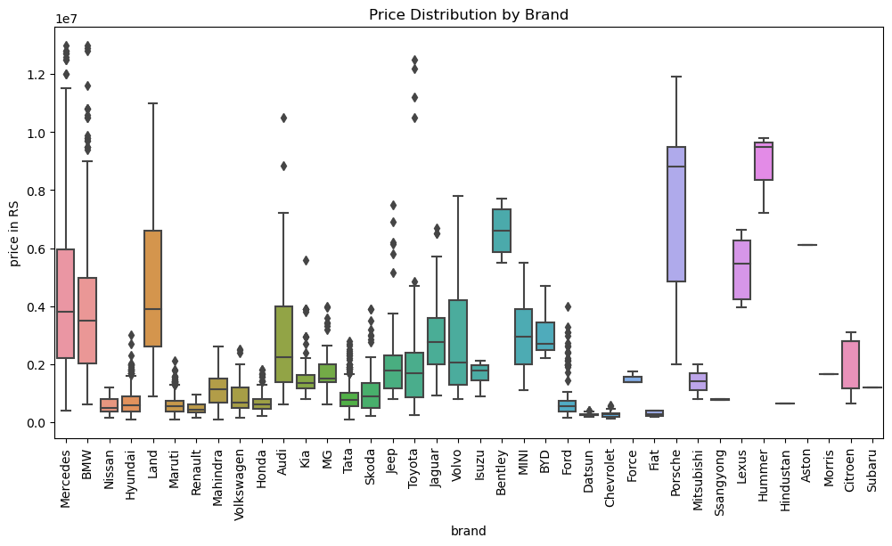

```python
 plt.figure(figsize=(12,6))
sns.boxplot(x='brand', y='price in RS', data=df)
plt.xticks(rotation=90)
plt.title('Price Distribution by Brand')
plt.show()
```

# Luxury brands like Bentley, Porsche, Mercedes, BMW, and Lexus tend to have the highest prices on average, with a wider price range. On the other hand, brands like Maruti, Hyundai, Tata, and Datsun have lower average prices, making them more affordable options.

# Is there a relationship between a car’s age and its price?

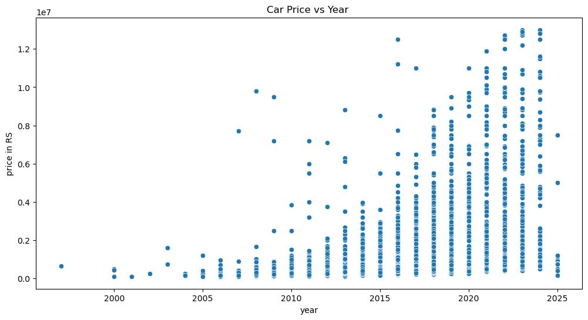

```python
plt.figure(figsize=(12,6))
sns.scatterplot(x='year', y='price in RS',  data=df)
plt.title('Car Price vs Year ')
plt.show()
```

# Newer cars tend to have higher prices, while older cars generally have lower prices, indicating depreciation over time. However, some older models still hold high value, likely due to being luxury or rare models.